# ggplot2-deviation

Compare variation in values between small number of items (or categories) with respect to a fixed reference. 比较数据之间偏差

# 1.发散条形图Diverging bars

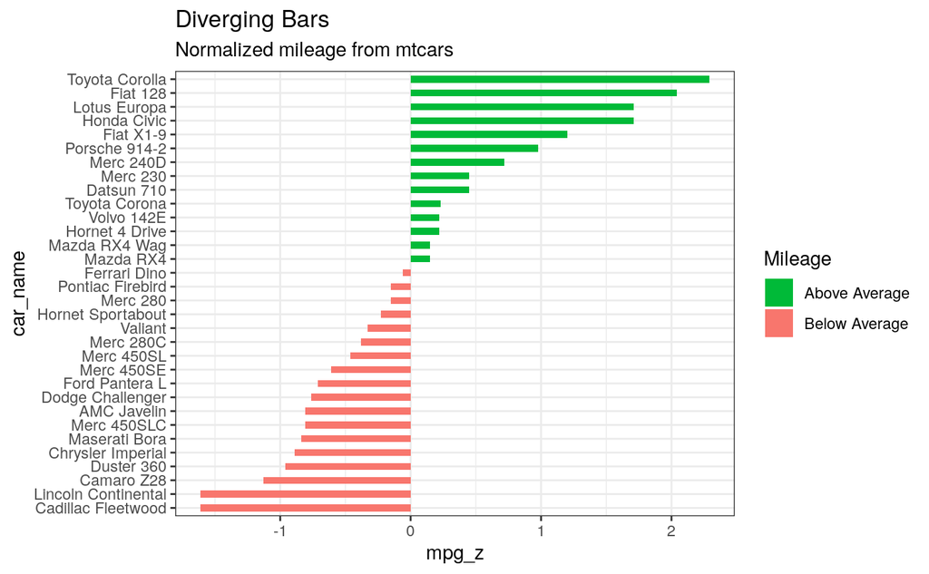

```r
library(ggplot2)
theme_set(theme_bw())

data('mtcars')
mtcars$car_name <- rownames(mtcars)
mtcars$mpg_z <- round((mtcars$mpg - mean(mtcars$mpg))/sd(mtcars$mpg), 2)

mtcars$mpg_type <- ifelse(mtcars$mpg_z < 0, 'below', 'above')
mtcars <- mtcars[order(mtcars$mpg_z), ]
mtcars$car_name <- factor(mtcars$car_name, levels = mtcars$car_name)

ggplot(mtcars, aes(x=car_name, y=mpg_z, label=mpg_z)) +
  geom_bar(stat = 'identity', aes(fill=mpg_type), width = 0.5) +
  scale_fill_manual(name='Mileage',
                    labels = c('Above Average', 'Below Average'),
                    values = c('above'='#00ba38', 'below'='#f8766d')) +
  labs(subtitle = 'Normalized mileage from mtcars',
       title = 'Diverging Bars') +
  coord_flip()
```

如果不设置为因子，则在绘图的时候，会按照car_name的ASCII进行排序 在单细胞聚类的过程中，往往就需要将聚得的类转换为因子以保持顺序，不然图例会出现c1,c10,c11,c12,c2,c3,c4,c5,c6,c7,c8,c9的排序现象

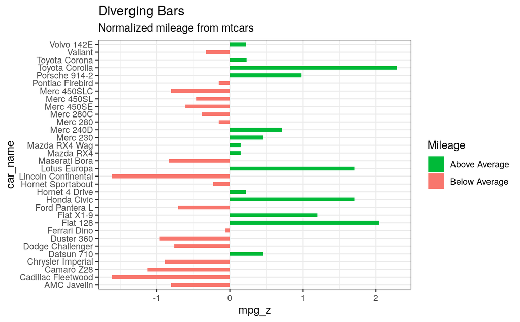

```r
library(ggplot2)
theme_set(theme_bw())

data('mtcars')
mtcars$car_name <- rownames(mtcars)
mtcars$mpg_z <- round((mtcars$mpg - mean(mtcars$mpg))/sd(mtcars$mpg), 2)

mtcars$mpg_type <- ifelse(mtcars$mpg_z < 0, 'below', 'above')
mtcars <- mtcars[order(mtcars$mpg_z), ]
# mtcars$car_name <- factor(mtcars$car_name, levels = mtcars$car_name) #转换为因子，可以确保顺序不变

ggplot(mtcars, aes(x=car_name, y=mpg_z, label=mpg_z)) +
  geom_bar(stat = 'identity', aes(fill=mpg_type), width = 0.5) +
  scale_fill_manual(name='Mileage',
                    labels = c('Above Average', 'Below Average'),
                    values = c('above'='#00ba38', 'below'='#f8766d')) +
  labs(subtitle = 'Normalized mileage from mtcars',
       title = 'Diverging Bars') +
  coord_flip()
```

# 2. 棒棒糖图 Diverging Lollipop Chart

这里使用geom_point和geom_segment来模拟棒棒糖 很巧妙，现绘制一个点图图层，然后在加上一个线段图层，线段的长度由对应的y值决定。这样就模拟出一个棒棒糖图形

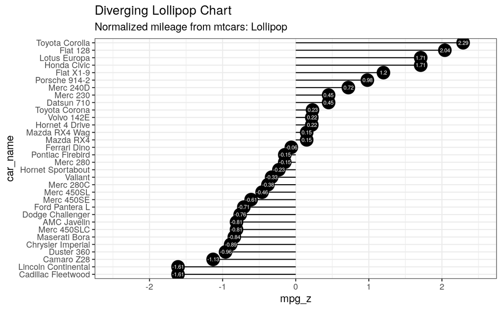

# 3.点图

这里使用到了scale_color_manual，相比与之前的scale_fill_manual，虽然都是用于设置颜色的，但稍有不同 scale_color_manual：

这个函数用于手动设置图形中颜色的比例尺（scale）。 它通常与映射到aes()中的color美学属性一起使用。 scale_color_manual允许你为离散变量的每个水平（level）指定一个颜色。 它常用于为条形图、点图、线图等的元素（如点、线）指定颜色。 scale_fill_manual：

这个函数用于手动设置图形中填充颜色的比例尺。 它通常与映射到aes()中的fill美学属性一起使用。 scale_fill_manual允许你为填充元素（如条形图、区域图、多边形等）的离散变量的每个水平指定一个颜色。 它常用于为条形图、区域图、热图等的填充部分指定颜色。 使用场景： 当你需要为图形中的元素（如线条、点）指定颜色时，使用scale_color_manual()。 当你需要为图形中的填充区域（如条形图的条形、热图中的单元格）指定颜色时，使用scale_fill_manual()。

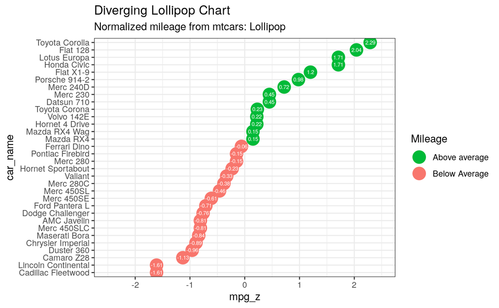

```r
library(ggplot2)
theme_set(theme_bw())

data('mtcars')
mtcars$car_name <- rownames(mtcars)
mtcars$mpg_z <- round((mtcars$mpg - mean(mtcars$mpg))/sd(mtcars$mpg), 2)

mtcars$mpg_type <- ifelse(mtcars$mpg_z < 0, 'below', 'above')
mtcars <- mtcars[order(mtcars$mpg_z), ]
mtcars$car_name <- factor(mtcars$car_name, levels = mtcars$car_name) #转换为因子，可以确保顺序不变


ggplot(data = mtcars, aes(x=car_name, y=mpg_z, label=mpg_z)) +
  geom_point(stat = 'identity', aes(col=mpg_type), size=6) +
  geom_text(color='white', size=2) +
  scale_color_manual(name='Mileage',
                     labels=c('Above average', 'Below Average'),
                     values=c('above'='#00ba38','below'='#f8766d'))+
  labs(title='Diverging Lollipop Chart',
       subtitle='Normalized mileage from mtcars: Lollipop') +
  ylim(-2.5, 2.5) +
  coord_flip()
```

```r
NA
```

# 4. 区域图 Area Chart

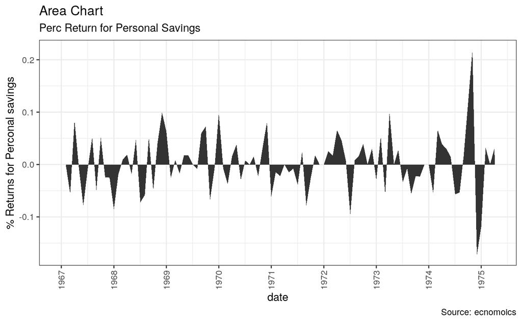